# Are Domestic Soccer Players Overpaid?

## Introduction

Most soccer leagues (and in fact many sports other sports leagues around the world) have rules limiting the number of foreign players that any team can have on their squad. In England’s Premier League, the Homegrown Player Rule requires that each team has a minimum of 8 ‘homegrown’ (or ‘domestic’) players on their 25 man sqad. I’ve often wondered if rules like this actually result in domestic players being overvalued. What else could explain Manchester United paying over 30 million pounds for an average player like Luke Shaw when he was just a teenager?!

For this project, we will attempt to answer the inferential question: **Are domestic soccer players overpaid?** Or in a more statistical context, we will be *testing the hypothesis that the mean overpaid index is greater for domestic players than foreign players*.

## Methodology

### Data Sources

For this project, we sourced player salaries and attributes from the [FIFA 19 complete player dataset](https://www.kaggle.com/karangadiya/fifa19) (Gadiya n.d.) from Kaggle. The dataset was downloaded and uploaded to one of our team member’s public github repository (see [here](https://raw.githubusercontent.com/mglu123/live_dash_demo/master/data-2.csv)).

Unfortunately, the FIFA dataset does not include information on leagues and locations, so we needed another data source to be able to determine whether a player is a domestic or foreign player. To be able to link clubs with a league location, we manually created a dictionary table of `Club`, `League`, and `Country` values sourced from the official [EA Games website](https://www.ea.com/games/fifa/news/fifa-19-leagues-and-teams) (Games 2019) and uploaded it to another public github repo (located [here](https://github.com/hwilliams10/fifa_data/blob/master/clubs_and_leagues.csv)).

### Exploratory Data Analysis

| Feature | Correlation Coefficient |
| --- | --- |
| Club_Value | 0.7111105 |
| International.Reputation | 0.6776594 |
| Overall FIFA Ranking | 0.5856002 |
| Reactions | 0.5134063 |
| Potential | 0.4935512 |
| Composure | 0.4663572 |

From Table 1, we see that the overall FIFA ranking is reasonably correlated with a player’s wage, but not as highly as one might expect. We also see that it is likely that the richest clubs also have the highest paid players which is intuitive.

*Note: The EDA analysis is performed by the `eda.py` script in the `src` directory. Additional details on the EDA process and findings are presented in the [EDA Report](https://github.com/UBC-MDS/DSCI_522_G410/blob/master/doc/eda_report.md) in the `doc` directory*

### Assumptions

We decided to limit our analysis to the top five global soccer leagues:

- Premier League (England)
- LaLiga (Spain)
- Bundesliga (Germany)
- Serie A (Italy)
- Ligue 1 (France)

To measure how overrated a player is, we decided to create an `Overpaid_Index`. This index was calculated as a player’s total salary (in millions) divided by their overall FIFA rating (which is a measure of how ‘good’ a player is) and multiplied by 1000.

[figure not shown]

### Wrangling and Cleaning

When we first went to join the dataframes, there were many mismatching `Club` names between the two datasets (for example, things like `Manchester United` versus `Manchester Utd`). After joining the tables,we also made new columns for the following features:

- `Salary`(in millions) was calculated based on the weekly `Wage` data from the FIFA dataset
- `Domestic` was assigned a value of 1 when a player had the same `Nationality` as the league’s `Country`
- `Overpaid_Index` was calculated as described above

The joining of the two dataframes, and this wrangling and cleaning step is performed by the `cleaning_leagues_table.r` script in the `src` directory using the programming language R (R Core Team 2019) and the tidyverse (Wickham 2017) package.

### Analysis and Results

To test our hypothesis, we used R’s (R Core Team 2019) `lm()` function to build linear models and the `broom` (Robinson and Hayes 2019) package to view and interpret results. Our steps were as follows:

- First, we fit a simple linear model associating `Overpaid_Index` with the player type (either `Domestic` or `Foreign`) as a baseline.
- We then fit an additive linear model to see the effect of both `League` and the player type (either `Domestic` or `Foreign`) on the `Overpaid_Index`.
- We also fit a linear model with interaction to see whether the relation between the player type and `Overpaid_Index` changes for different leagues.

Once we had our three models, we used the `anova()` function to see if our additive and interaction models with the extra `League` term significantly improved our simple baseline model. Our findings were as follows:

- *Comparing additive model to baseline*: adding the extra `League` term in the additive model improved the baseline model at the 0.05 significance level (the p-value was 1.82e-36).
- *Comparing model with interaction to additive*: adding the interaction term significantly improved the additive model at the 0.05 significance level (the p-value was 1.1e-06).

Based on these results, we concluded that it was important to use our interaction model and look at the relationship for each league. The overall results are summarized in Table 2 below.

**Table 2. Results of Comparing the Relationship of Player Origin to Overpaid Index**

| League | Domestic Mean Overpaid Index | Foreign Mean Overpaid Index | Difference | p_value |
| --- | --- | --- | --- | --- |
| Bundesliga | 14.1 | 18.6 | -4.49 | 2.16e-25 |
| LaLiga | 16 | 35 | -19 | 5.1e-06 |
| Ligue 1 | 11 | 17.4 | -6.46 | 0.229 |
| Premier League | 23.7 | 42 | -18.3 | 2.72e-25 |
| Serie A | 15.8 | 23.7 | -7.86 | 0.0828 |

Figure 1 shows all the data graphically.

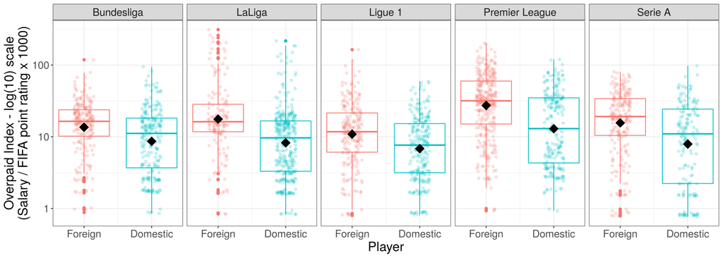

*Note: The analysis described above is performed by the `analysis_overpaid.r` script in the `src` directory.*

## Conclusions

Not only was our original hypothesis disproven; but instead we found that the opposite was true!

*This report was prepared with R’s (R Core Team 2019) `kableExtra` (Zhu 2019) and `knitr` (Xie 2014) packages*

# References

Gadiya, Karan. n.d. “FIFA 19 Complete Player Dataset.” Accessed January 16, 2020. https://www.kaggle.com/karangadiya/fifa19.

Games, EA. 2019. “FIFA 19 All Teams and Clubs.” 2019.

R Core Team. 2019. *R: A Language and Environment for Statistical Computing*. Vienna, Austria: R Foundation for Statistical Computing. https://www.R-project.org/.

Robinson, David, and Alex Hayes. 2019. *Broom: Convert Statistical Analysis Objects into Tidy Tibbles*. https://CRAN.R-project.org/package=broom.

Wickham, Hadley. 2017. *Tidyverse: Easily Install and Load the ’Tidyverse’*. https://CRAN.R-project.org/package=tidyverse.

Xie, Yihui. 2014. “Knitr: A Comprehensive Tool for Reproducible Research in R.” In *Implementing Reproducible Computational Research*, edited by Victoria Stodden, Friedrich Leisch, and Roger D. Peng. Chapman; Hall/CRC. http://www.crcpress.com/product/isbn/9781466561595.

Zhu, Hao. 2019. *KableExtra: Construct Complex Table with ’Kable’ and Pipe Syntax*. https://CRAN.R-project.org/package=kableExtra.